# Team Project 1 Debrief

## What the class cut

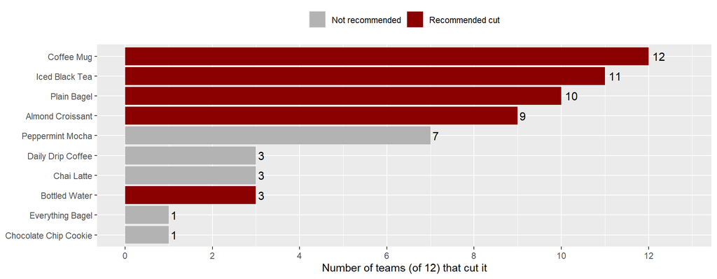

Ten of 12 teams got **four of the five**; no team got all five. Almost every team found Coffee Mug, Iced Black Tea, and Plain Bagel. **Bottled Water** was the one most teams missed.

## The five cuts

| Cut | Why |
| --- | --- |
| Bottled Water | Thin margin, and nothing else sells because of it |
| Almond Croissant | Its sales only come at ~50% off; after the discounts it barely earns anything |
| Plain Bagel | Everything Bagel replaced it in July; it now earns less than anything else on the menu |
| Iced Black Tea | Last on revenue; whatever its cost, it can't earn more than that |
| Coffee Mug | Good margin, far too few sales |

- **Keep:** Daily Drip Coffee, because it brings in Caramel Macchiato sales.
- **Keep, seasonally:** Peppermint Mocha, which is weak for ten months and one of the best items in November and December.

## Seven traps, most common first

[output not shown]

## Trap 1: Bottled Water 9 of 12 teams

## “Never bought alone” isn’t “drives a sale”

Drip Coffee and Bottled Water look alike: the two biggest sellers, both $2, both with the thinnest margins on the menu. Both are almost never bought alone.

The question that separates them: **when it’s in the basket, is a specific high-value item there more often than usual?**

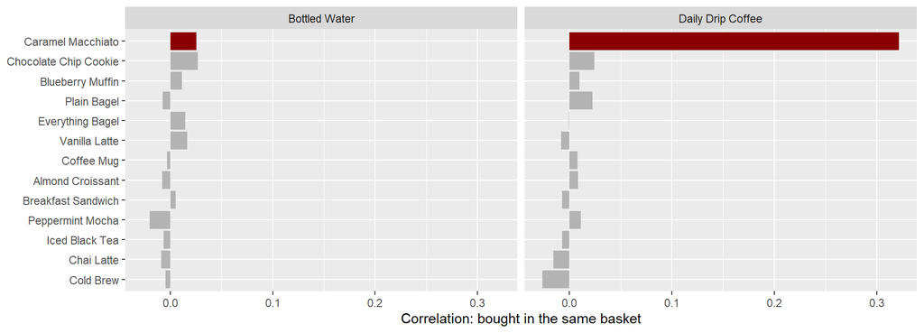

## One real link, one non-link

| Baskets containing... | ...that also have a Caramel Macchiato |
| --- | --- |
| Daily Drip Coffee | 48% |
| Bottled Water | 23% |
| (all baskets) | 21% |

- Drip Coffee baskets are **far more likely** to include a Macchiato, the most profitable item on the menu.
- Water baskets include a Macchiato at the **usual** rate. Water is popular on its own; it doesn’t bring anything else in. So it goes.
- **Raw co-occurrence misleads:** Water shows up next to Cold Brew a lot because *both are popular*, not because one sells the other. Compare against what you’d expect by chance.

A low-margin item earns its place only if you can **show** what it brings in.

## Weak for ten months, a star for two

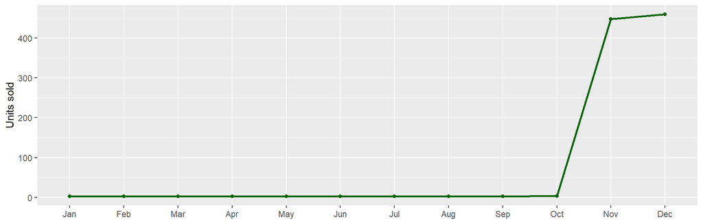

- On the annual total it looks like a cut: 937 units, $3,470 profit.
- But nearly all of that comes in **November and December**, when it sells like one of the best items on the menu.
- Corporate wants room for a **seasonal lineup**. Peppermint Mocha already *is* one. Take it off the menu in the off-season and bring it back for the holidays, rather than cutting it outright.

## Trap 3: Iced Black Tea’s missing cost 5 of 12 teams

## You don’t need a number you don’t have

`product_cost.csv` has no row for Iced Black Tea. Several teams **made up a cost** (a median, an average, an online estimate) and then ranked it as if the number were real. One team’s guess of $0.30 kept the tea on the menu.

| Revenue rank (1 = lowest) | Product | Units | Revenue |
| --- | --- | --- | --- |
| 1 | Iced Black Tea | 846 | $2,538 |
| 2 | Coffee Mug | 294 | $3,528 |
| 3 | Peppermint Mocha | 937 | $5,154 |
| 4 | Chocolate Chip Cookie | 2,860 | $7,641 |

- It’s **last on revenue**, and cost can only subtract from revenue.
- Even at a cost of **$0**, its profit would be only $2,540, still among the five lowest earners.
- So it’s a cut **without knowing its cost at all**. If you do fill in a number, say so and show the answer doesn’t depend on it.

## Trap 4: Cutting Daily Drip Coffee 3 of 12 teams

## The worst margin on the menu, and still a keep

A ranking tells you **where to look**, not **what to conclude**.

## Trap 5: Almond Croissant’s discounts 3 of 12 teams

## Count the discounts before you rank

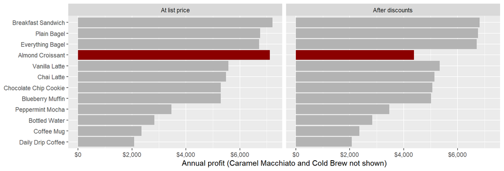

At list price the croissant earns about **$7,110**. Once its four ~50%-off months are counted, it’s about **$4,390**, dropping from #11 to #5 of 14 (1 = lowest). The discounts that drove its volume are also what wiped out its profit.

## Trap 6: Plain Bagel’s annual total 2 of 12 teams

## Annual totals hide time

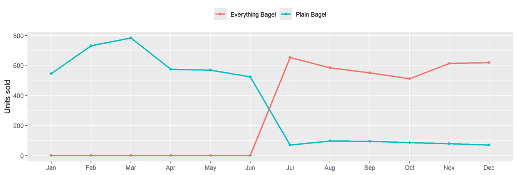

On its full-year total Plain Bagel looks healthy, mid-pack on every measure. But it **collapses in July and stays down**, the month Everything Bagel launches. The annual total describes a product that no longer sells.

## Was the bagel drop just seasonal?

A summer dip would hit the whole bakery case. It didn’t:

[output not shown]

The other bakery items barely move. Plain Bagel’s lost sales show up in Everything Bagel, so demand **moved** to another product; it didn’t disappear.

## Trap 7: Cold Brew’s duplicate cost rows 0 of 12 teams

## Check the join before you trust it

```r
c(rows = nrow(product_cost), products = n_distinct(product_cost$product_id))
##     rows products
##       16       14

product_info %>% anti_join(product_cost, by = "product_id") %>% select(product_name)
## # A tibble: 1 × 1
##   product_name
##   <chr>
## 1 Iced Black Tea

product_cost %>% count(product_id) %>% filter(n > 1)
## # A tibble: 1 × 2
##   product_id     n
##   <chr>      <int>
## 1 P09            3
```

16 rows, but only 14 products for a 15-item menu. `nrow()` alone makes it look like one stray extra row. `anti_join()` and `count()` show the two real problems: Iced Black Tea is **missing**, and Cold Brew is **listed three times**. Joined as-is, Cold Brew’s sales triple. **Every team caught this.**